# Analisis Bivariado - Tablas y Graficos

Mariano Ignacio Prado Urbano

16 de setiembre, 2025

# 1 Cargar la base de datos

La base de datos fue recolectada en el año 2015, en Mexico. Tienen las variables precio, avaluó y administración están en millones de pesos. La variable administración corresponde al valor mensual en pesos por el servicio de administración del edificio. La variable terminado hace referencia a si el dpto. tiene reformas o mejoras en relación al estado del dpto nuevo.

```r
datos <- read.table(file = 'https://tinyurl.com/hwhb769', header=T)
datos
```

|  | precio | mt2 | ubicacion | estrato | alcobas | banos | balcon | parqueadero | administracion | avaluo | terminado |
| --- | --- | --- | --- | --- | --- | --- | --- | --- | --- | --- | --- |
| 1 | 79.000 | 43.16 | norte | 3 | 3 | 1 | si | si | 0.050000 | 14.923002 | no |
| 2 | 93.000 | 56.92 | norte | 2 | 2 | 1 | si | si | 0.069000 | 27.000000 | si |
| 3 | 100.000 | 66.40 | norte | 3 | 2 | 2 | no | no | 0.000000 | 15.738427 | no |
| 4 | 123.000 | 61.85 | norte | 2 | 3 | 2 | si | si | 0.130000 | 27.000000 | no |
| 5 | 135.000 | 89.80 | norte | 4 | 3 | 2 | si | no | 0.000000 | 39.567000 | si |
| 6 | 140.000 | 71.00 | norte | 3 | 3 | 2 | no | si | 0.120000 | 31.145508 | si |
| 7 | 145.000 | 54.83 | norte | 3 | 2 | 2 | si | si | 0.140000 | 27.000000 | si |
| 8 | 160.000 | 69.00 | norte | 3 | 3 | 2 | si | si | 0.127000 | 29.672435 | si |
| 9 | 160.000 | 93.00 | norte | 4 | 4 | 2 | si | no | 0.000000 | 28.956220 | si |
| 10 | 175.000 | 60.88 | norte | 4 | 3 | 2 | si | si | 0.123000 | 26.635132 | si |

[output cut: 684 more lines]

```r
str(datos)
```

```
'data.frame':   694 obs. of  11 variables:
 $ precio        : num  79 93 100 123 135 140 145 160 160 175 ...
 $ mt2           : num  43.2 56.9 66.4 61.9 89.8 ...
 $ ubicacion     : chr  "norte" "norte" "norte" "norte" ...
 $ estrato       : int  3 2 3 2 4 3 3 3 4 4 ...
 $ alcobas       : int  3 2 2 3 3 3 2 3 4 3 ...
 $ banos         : int  1 1 2 2 2 2 2 2 2 2 ...
 $ balcon        : chr  "si" "si" "no" "si" ...
 $ parqueadero   : chr  "si" "si" "no" "si" ...
 $ administracion: num  0.05 0.069 0 0.13 0 0.12 0.14 0.127 0 0.123 ...
 $ avaluo        : num  14.9 27 15.7 27 39.6 ...
 $ terminado     : chr  "no" "si" "no" "no" ...
```

# 2 Descriptores numericos

# 3 Media

```r
mean(datos$mt2) # Univariado
```

```
[1] 120.9438
```

Media desagregada

```r
by(datos$mt2, datos$estrato, mean) # Bivariado
```

```
datos$estrato: 2
[1] 62.22125
----------------------------------------------------------------------------------
datos$estrato: 3
[1] 71.22062
----------------------------------------------------------------------------------
datos$estrato: 4
[1] 89.78478
----------------------------------------------------------------------------------
datos$estrato: 5
[1] 116.2239
----------------------------------------------------------------------------------
datos$estrato: 6
[1] 176.5618
```

# 4 Mediana

```r
median(datos$mt2)
```

```
[1] 97.5
```

Mediana desagregada

```r
by(datos$mt2, datos$estrato, median)
```

```
datos$estrato: 2
[1] 58.46
----------------------------------------------------------------------------------
datos$estrato: 3
[1] 64
----------------------------------------------------------------------------------
datos$estrato: 4
[1] 84
----------------------------------------------------------------------------------
datos$estrato: 5
[1] 102
----------------------------------------------------------------------------------
datos$estrato: 6
[1] 153
```

## 4.1 Moda

```r
library(DescTools)
Mode(datos$precio)
```

```
[1] 220
attr(,"freq")
[1] 20
```

Moda desagregada

```r
by(datos$mt2, datos$estrato, Mode)
```

```
datos$estrato: 2
[1] NA
attr(,"freq")
[1] NA
----------------------------------------------------------------------------------
datos$estrato: 3
[1] 60
attr(,"freq")
[1] 11
----------------------------------------------------------------------------------
datos$estrato: 4
[1] 70
attr(,"freq")
[1] 6
----------------------------------------------------------------------------------
datos$estrato: 5
[1]  87 120
attr(,"freq")
[1] 5
----------------------------------------------------------------------------------
datos$estrato: 6
[1] 85
attr(,"freq")
[1] 5
```

## 4.2 Desviacion estandar

```r
sd(datos$mt2)
```

```
[1] 74.69549
```

DE desagregado

```r
by(datos$mt2, datos$estrato, sd)
```

```
datos$estrato: 2
[1] 18.81655
----------------------------------------------------------------------------------
datos$estrato: 3
[1] 23.9861
----------------------------------------------------------------------------------
datos$estrato: 4
[1] 39.52138
----------------------------------------------------------------------------------
datos$estrato: 5
[1] 53.23306
----------------------------------------------------------------------------------
datos$estrato: 6
[1] 87.34226
```

## 4.3 Coeficiente de variacion

```r
library(raster)
cv(datos$precio)
```

```
[1] 77.92446
```

CV desagregado

```r
by(datos$mt2, datos$estrato, cv)
```

```
datos$estrato: 2
[1] 30.24135
----------------------------------------------------------------------------------
datos$estrato: 3
[1] 33.67858
----------------------------------------------------------------------------------
datos$estrato: 4
[1] 44.01791
----------------------------------------------------------------------------------
datos$estrato: 5
[1] 45.80215
----------------------------------------------------------------------------------
datos$estrato: 6
[1] 49.46839
```

## 4.4 Coeficiente de Asimetria

```r
library(e1071)
skewness(datos$precio)
```

```
[1] 2.333216
```

CA desagregado

```r
by(datos$mt2, datos$estrato, skewness)
```

```
datos$estrato: 2
[1] 0.8251878
----------------------------------------------------------------------------------
datos$estrato: 3
[1] 1.11844
----------------------------------------------------------------------------------
datos$estrato: 4
[1] 2.027209
----------------------------------------------------------------------------------
datos$estrato: 5
[1] 3.211559
----------------------------------------------------------------------------------
datos$estrato: 6
[1] 1.131868
```

# 5 Graficos de Variables

## 5.1 Variables cualitativas

**Estrato**: Variable categórica **ordinal o jerarquica**, **requiere convertirlo en ordinal**.

```r
unique(datos$estrato)
```

```
[1] 3 2 4 5 6
```

```r
str(datos$estrato)
```

```
 int [1:694] 3 2 3 2 4 3 3 3 4 4 ...
```

```r
# Convirtiendo la variable estrato en una cualitativa ordinal.
datos$estrato <- ordered(datos$estrato,levels=c(2,3,4,5,6))
str(datos$estrato)
```

```
 Ord.factor w/ 5 levels "2"<"3"<"4"<"5"<..: 2 1 2 1 3 2 2 2 3 3 ...
```

```r
unique(datos$estrato)
```

```
[1] 3 2 4 5 6
Levels: 2 < 3 < 4 < 5 < 6
```

## 5.2 Tabla de frecuencias absoluta (Univariado)

Cantidad de departamentos por estrato

```r
tabla1 <- table(datos$estrato)
tabla1
```

```
  2   3   4   5   6
  8 161 138 145 242
```

```r
data.frame(tabla1)
```

| Var1 | Freq |
| --- | --- |
| 2 | 8 |
| 3 | 161 |
| 4 | 138 |
| 5 | 145 |
| 6 | 242 |

```r
NA
```

## 5.3 Tabla de frecuencias acumulada

```r
Tablacum1 <- cumsum(tabla1)
data.frame(Tablacum1)
```

|  | Tablacum1 |
| --- | --- |
| 2 | 8 |
| 3 | 169 |
| 4 | 307 |
| 5 | 452 |
| 6 | 694 |

## 5.4 Tabla de frecuencia relativa porcentual

% de departamentos por estrato

```r
tablap1 <- round(addmargins(prop.table(tabla1)*100), 2)
tablap1
```

```
     2      3      4      5      6    Sum
  1.15  23.20  19.88  20.89  34.87 100.00
```

```r
data.frame(tablap1)
```

| Var1 | Freq |
| --- | --- |
| 2 | 1.15 |
| 3 | 23.20 |
| 4 | 19.88 |
| 5 | 20.89 |
| 6 | 34.87 |
| Sum | 100.00 |

## 5.5 Tabla de frecuencia absoluta y relativa porcentual

```r
#Otra manera
#install.packages("janitor")
library(janitor)
data.frame(tabyl(datos$estrato))
```

| datos.estrato | n | percent |
| --- | --- | --- |
| 2 | 8 | 0.01152738 |
| 3 | 161 | 0.23198847 |
| 4 | 138 | 0.19884726 |
| 5 | 145 | 0.20893372 |
| 6 | 242 | 0.34870317 |

```r
NA
```

## 5.6 Tabla de frecuencia relativa porcentual acumulada

```r
frec_relativa_porc_acumul <- cumsum(tabla1*100)/margin.table(tabla1)
data.frame(frec_relativa_porc_acumul)
```

|  | frec_relativa_porc_acumul |
| --- | --- |
| 2 | 1.152738 |
| 3 | 24.351585 |
| 4 | 44.236311 |
| 5 | 65.129683 |
| 6 | 100.000000 |

## 5.7 Grafico de barras (Univariado)

```r
tablag <- round(prop.table(tabla1)*100, 2)
tablag
```

```
    2     3     4     5     6
 1.15 23.20 19.88 20.89 34.87
```

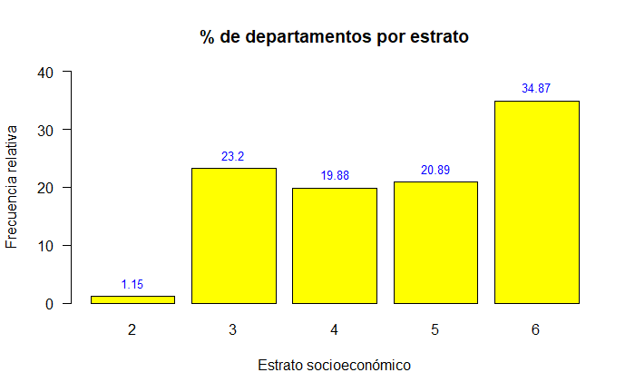

```r
barras <- barplot(tablag  # Llama la tabla
                  ,ylim=c(0, 40)
                  ,xlab='Estrato socioeconómico'
                  ,ylab='Frecuencia relativa',
                  las=1
                  ,col='yellow'
                  ,main = "% de departamentos por estrato")

text(x=barras, y=tablag, pos=3, cex=0.8, col="blue", label=round(tablag, 4))
```

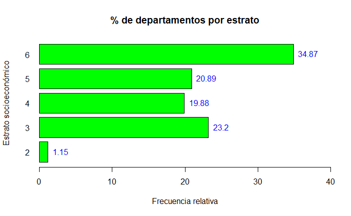

```r
barras <- barplot(tablag
                  ,xlim=c(0, 40)
                  ,ylab='Estrato socioeconómico'
                  ,xlab='Frecuencia relativa',
                  las=1
                  ,col='green'
                  ,horiz = TRUE
                  ,main = "% de departamentos por estrato")
text(y=barras, x=tablag, pos=4, cex=1.0, col="blue", label=round(tablag, 4))
```

## 5.8 Grafico de Pie

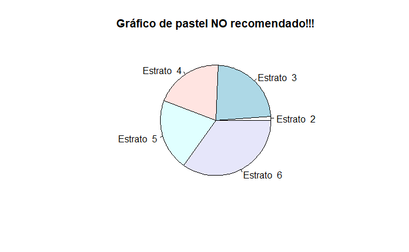

```r
nombres <- paste('Estrato ', 2:6)
pie(x=tablag, labels=nombres, main='Gráfico de pastel NO recomendado!!!')
```

```r
tablag
```

```
    2     3     4     5     6
 1.15 23.20 19.88 20.89 34.87
```

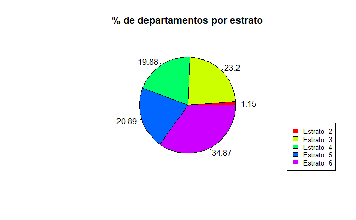

```r
nombres <- paste('Estrato ', 2:6)
pie(x=tablag
    ,labels= tablag
    ,main='% de departamentos por estrato'
    ,col= rainbow(length(tablag)))

legend("bottomright", legend = nombres, cex = 0.8, fill = rainbow(length(tabla1)))
```

## 5.9 Tabla Cruzada o de doble entrada (Bivariado - dos variables cualitativas) - Frecuencia absoluta

Cantidad de departamentos por estrato y estacionamiento

```r
tabla2 <- table(datos$parqueadero, datos$estrato)
addmargins(tabla2)
```

```
        2   3   4   5   6 Sum
  no    5  88  24   8   1 126
  si    3  73 114 137 241 568
  Sum   8 161 138 145 242 694
```

### 5.9.1 Frecuencias relativas

La suma de todos los % es 100%

% de departamentos por estrato y estacionamiento

```r
addmargins(round(prop.table(tabla2)*100, 2))
```

```
           2      3      4      5      6    Sum
  no    0.72  12.68   3.46   1.15   0.14  18.15
  si    0.43  10.52  16.43  19.74  34.73  81.85
  Sum   1.15  23.20  19.89  20.89  34.87 100.00
```

### 5.9.2 Frecuencias relativas - Fila

Las filas suman 100%

```r
addmargins(round(prop.table(tabla2, 1)*100, 2), 2)
```

```
          2      3      4      5      6    Sum
  no   3.97  69.84  19.05   6.35   0.79 100.00
  si   0.53  12.85  20.07  24.12  42.43 100.00
```

### 5.9.3 Frecuencias relativas - Columna

Las columnas suman 100%

```r
addmargins(round(prop.table(tabla2, 2)*100, 2), 1)
```

```
           2      3      4      5      6
  no   62.50  54.66  17.39   5.52   0.41
  si   37.50  45.34  82.61  94.48  99.59
  Sum 100.00 100.00 100.00 100.00 100.00
```

## 5.10 Grafico de barras de tabla cruzada

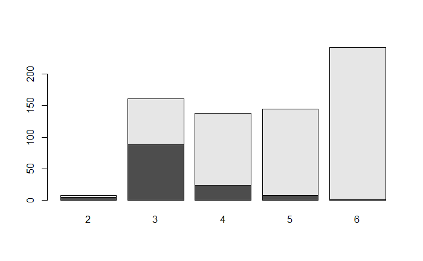

```r
barplot(tabla2)
```

```r
tabla2
```

```
       2   3   4   5   6
  no   5  88  24   8   1
  si   3  73 114 137 241
```

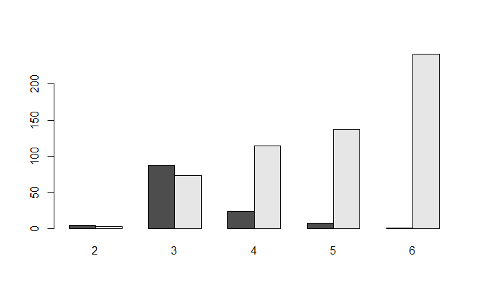

```r
barplot(tabla2, beside=TRUE)
```

## 5.11 Grafico de mosaicos (dos variables cualitativas)

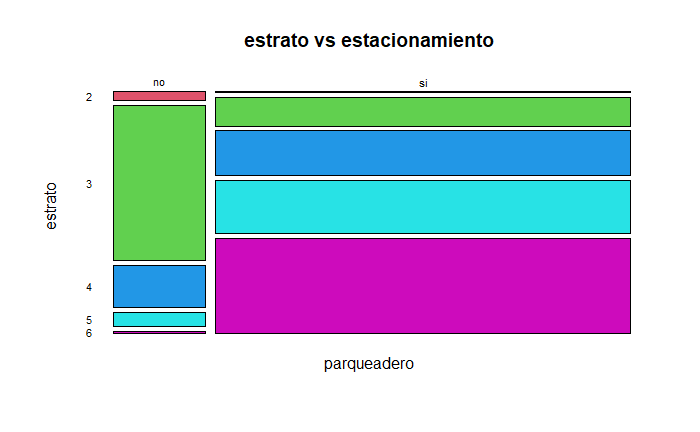

```r
library(stats)
mosaicplot(~ parqueadero + estrato, # Las variables cualitativas a cruzar
           ,data = datos # La tabla de datos
           ,color = 2:10 # vector de colores, T = banco y negro.
           ,las = 1
           ,main = "estrato vs estacionamiento") # estilo de los ejes
```

```r
tabla2
```

```
       2   3   4   5   6
  no   5  88  24   8   1
  si   3  73 114 137 241
```

# 6 Variables Cuantitativas

## 6.1 Histograma

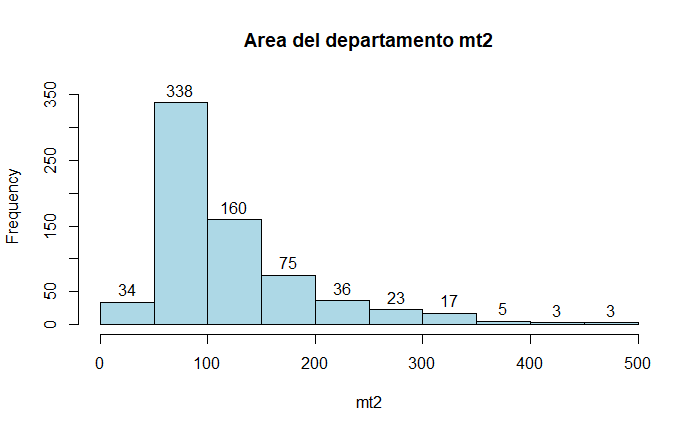

```r
hist(datos$mt2
     ,breaks = 10
     ,col = "lightblue"
     ,labels = TRUE
     ,ylim = c(0,360)
     ,main = "Area del departamento mt2"
     ,xlab = "mt2"
     )
```

```r
summary(datos$mt2)
```

```
   Min. 1st Qu.  Median    Mean 3rd Qu.    Max.
   26.0    71.0    97.5   120.9   141.8   500.0
```

```r
hist(datos$mt2
     ,plot = F
     )
```

```
$breaks
 [1]   0  50 100 150 200 250 300 350 400 450 500

$counts
 [1]  34 338 160  75  36  23  17   5   3   3

$density
 [1] 9.798271e-04 9.740634e-03 4.610951e-03 2.161383e-03 1.037464e-03 6.628242e-04 4.899135e-04 1.440922e-04
 [9] 8.645533e-05 8.645533e-05

$mids
 [1]  25  75 125 175 225 275 325 375 425 475

$xname
[1] "datos$mt2"

$equidist
[1] TRUE

attr(,"class")
[1] "histogram"
```

## 6.2 Boxlot

```r
summary(datos$mt2)
```

```
   Min. 1st Qu.  Median    Mean 3rd Qu.    Max.
   26.0    71.0    97.5   120.9   141.8   500.0
```

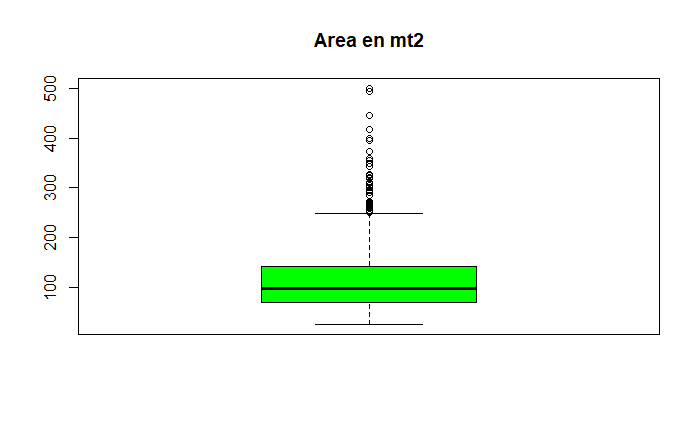

```r
caja <- boxplot(datos$mt2, col = "green",
        main = "Area en mt2")
```

```r
caja
```

```
$stats
      [,1]
[1,]  26.0
[2,]  71.0
[3,]  97.5
[4,] 142.0
[5,] 248.0

$n
[1] 694

$conf
          [,1]
[1,]  93.24171
[2,] 101.75829

$out
 [1] 250.00 264.00 253.00 255.30 418.00 250.00 258.00 290.00 324.00 294.00 418.00 271.00 320.00 311.00 325.00
[16] 326.05 350.00 325.00 355.00 320.00 284.00 324.00 300.00 324.00 260.00 260.00 350.00 250.00 284.00 251.00
[31] 268.00 267.00 272.00 500.00 305.00 360.00 300.00 309.00 272.00 324.00 396.00 342.00 262.00 500.00 373.00
[46] 291.00 318.00 445.00 399.00 255.00 261.00 254.00 305.00 494.00

$group
 [1] 1 1 1 1 1 1 1 1 1 1 1 1 1 1 1 1 1 1 1 1 1 1 1 1 1 1 1 1 1 1 1 1 1 1 1 1 1 1 1 1 1 1 1 1 1 1 1 1 1 1 1 1 1
[54] 1

$names
[1] ""
```

## 6.3 Cruzado una variable cuantitativa con una cualitativa (Bivariado)

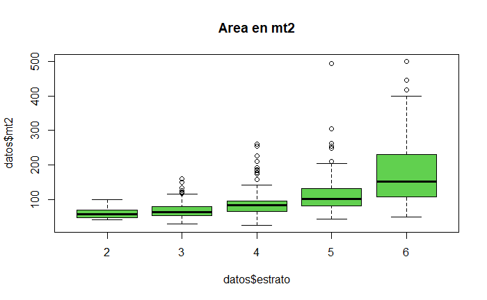

```r
caja2 <- boxplot(datos$mt2 ~ datos$estrato, col = 3,
        main = "Area en mt2")
```

```r
caja2
```

```
$stats
        [,1] [,2] [,3] [,4] [,5]
[1,]  43.000   30   26   44   50
[2,]  49.000   55   66   83  108
[3,]  58.460   64   84  102  153
[4,]  69.925   80   97  132  230
[5,] 100.000  117  143  204  399

$n
[1]   8 161 138 145 242

$conf
         [,1]     [,2]     [,3]      [,4]     [,5]
[1,] 46.77099 60.88696 79.83055  95.57062 140.6089
[2,] 70.14901 67.11304 88.16945 108.42938 165.3911

$out
 [1] 120 135 160 120 126 123 118 123 150 174 187 159 210 178 192 185 255 226 261 262 210 254 305 210 248 494
[27] 418 418 500 500 445

$group
 [1] 2 2 2 2 2 2 2 2 2 3 3 3 3 3 3 3 3 3 3 4 4 4 4 4 4 4 5 5 5 5 5

$names
[1] "2" "3" "4" "5" "6"
```

## 6.4 Cruzando una variable cuantitiva con cuantitativa (Bivariado)

Gráfico de dispersión

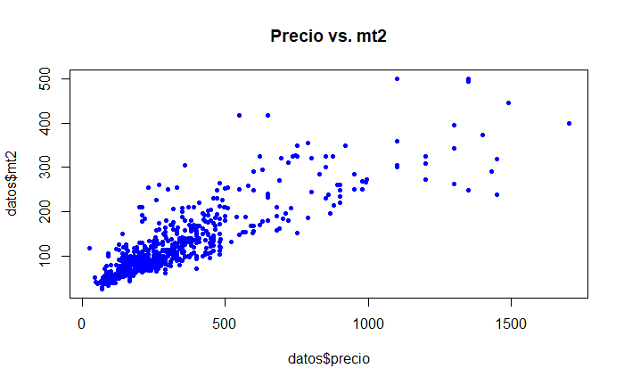

```r
plot(datos$precio, datos$ mt2,
     pch = 20,
     col = "blue",
     main = "Precio vs. mt2")
```

Función `smoothScatter` para visualizar datos atipicos.

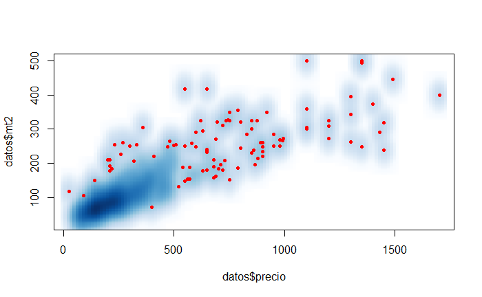

```r
smoothScatter(datos$precio,datos$mt2
              ,pch = 20
              ,col = "red"
              ,bandwidth = 20 #Ventana
              )
```

Puede que hayas notado que algunos puntos se muestran en el gráfico. Estos puntos se corresponden con los puntos de las áreas con las densidades regionales menores y son útiles para identificar datos atípicos.

## 6.5 Grafico de dispersión con colores

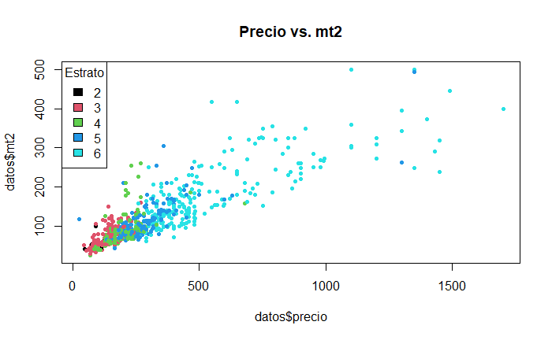

```r
plot(x = datos$precio, y = datos$mt2,
     pch = 20,
     col = factor(datos$estrato),
     main = "Precio vs. mt2")

legend(x = "topleft", legend = levels(factor(datos$estrato)), fill = c(1:5), title = "Estrato")
```

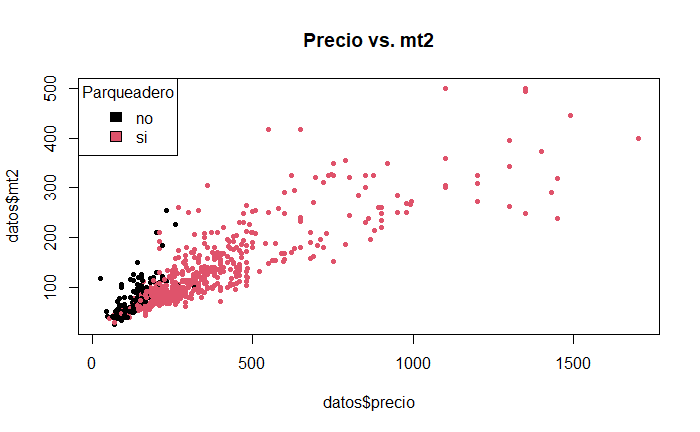

```r
plot(x = datos$precio, y = datos$mt2,
     pch = 20,
     col = factor(datos$parqueadero),
     main = "Precio vs. mt2")

legend(x = "topleft", legend = levels(factor(datos$parqueadero)), fill = c(1:2), title = "Parqueadero")
```

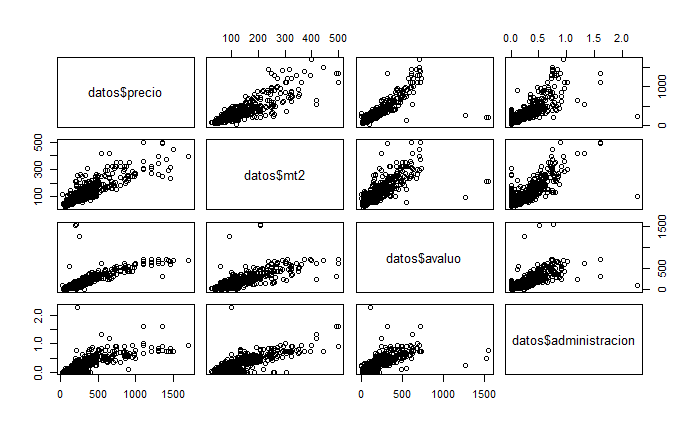

```r
pairs(~ datos$precio + datos$mt2 + datos$avaluo + datos$administracion)
```

## 6.7 Estrato vs Mt2 - Cualitativa vs Cuantitativa (Bivariado)

```r
summary(datos$precio)
```

```
   Min. 1st Qu.  Median    Mean 3rd Qu.    Max.
   25.0   160.0   245.0   317.8   380.0  1700.0
```

```r
library(dplyr)

datos %>%
  group_by(datos$estrato) %>%
  summarize(media = mean(mt2,na.rm=TRUE),
            sd = sd(mt2,na.rm=TRUE),
            cv = sd/media*100,
            p25 = quantile(mt2,0.25,na.rm=TRUE, type =3),
            mediana = median(mt2,na.rm=TRUE),
            p75 = quantile(mt2,0.75,na.rm=TRUE, type =3)
            ) %>%
 arrange(desc(media))
```

| datos$estrato | media | sd | cv | p25 | mediana | p75 |
| --- | --- | --- | --- | --- | --- | --- |
| 6 | 176.56178 | 87.34226 | 49.46839 | 108 | 153.00 | 230.00 |
| 5 | 116.22393 | 53.23306 | 45.80215 | 82 | 102.00 | 132.00 |
| 4 | 89.78478 | 39.52138 | 44.01791 | 66 | 84.00 | 97.00 |
| 3 | 71.22062 | 23.98610 | 33.67858 | 55 | 64.00 | 80.00 |
| 2 | 62.22125 | 18.81655 | 30.24135 | 44 | 58.46 | 61.85 |

El `arrange` le ordenamos de acuerdo a una variable

#### 6.7.0.1 Coeficiente de variación que tomamos para ejercicios

Como regla empírica, denominaremos al coeficiente de variación en función de tres rangos:

- Menor o igual a 30% será bajo.
- Mayor que 30% y menor o igual a 60% será medio
- Mayor a 60% será alto.

## 6.8 Diagrama de Densidad

```r
par(mfrow = c(1, 2)) # Genera los espacios
hist(datos$mt2,  breaks = 10, col = "lightblue", freq = FALSE, main = "Histograma en mt2")
lines(density(datos$mt2), lwd = 2, col = "red")
```

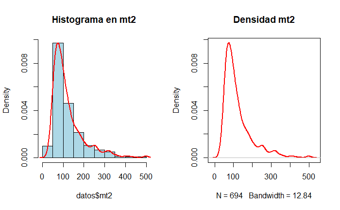

```r
plot(density(datos$mt2), lwd = 2, col = "red", main = "Densidad mt2")
```

```r
summary(datos$mt2)
```

```
   Min. 1st Qu.  Median    Mean 3rd Qu.    Max.
   26.0    71.0    97.5   120.9   141.8   500.0
```

# 7 Covariancia (Bivariado )

La covarianza es el valor que refleja en qué cuantía **dos variables aleatorias CUANTITATIVAS** que varían de forma conjunta respecto a sus medias.

```r
cov(datos$precio,datos$mt2)
```

```
[1] 15874.11
```

Cuando el mt2 sube, el precio también sube, o viceversa.

## 7.1 Propiedades de la Covariancia

### 7.1.1 Cov (X, b) = 0, b es una constante.

```r
b <- runif(694, min=4, max=4)

cov(datos$precio, b)
```

```
[1] 0
```

### 7.1.2 Cov (X, X) = Var(X) , la covarianza de una variable y de sí misma es igual a su varianza.

```r
cov(datos$precio, datos$precio)
```

```
[1] 61313.15
```

```r
var(datos$precio)
```

```
[1] 61313.15
```

### 7.1.3 Cov (b·X, c·Y) = c·b ·Cov(X,Y), b y c dos constantes.

```r
b <- runif(694, min=4, max=4)
c <- runif(694, min=6, max=6)

cov(datos$precio*b, datos$mt2*c)
```

```
[1] 380978.6
```

```r
4*6* cov(datos$precio,datos$mt2)
```

```
[1] 380978.6
```

### 7.1.4 Cov (b+X, c+Y) = Cov(X,Y) sumar dos constantes cualesquiera a cada variable, no afecta a la covarianza.

```r
cov(datos$precio+b, datos$mt2+c)
```

```
[1] 15874.11
```

```r
cov(datos$precio,datos$mt2)
```

```
[1] 15874.11
```

# 8 Correlacion

```r
round(cor(datos$precio,datos$mt2), 2)
```

```
[1] 0.86
```

La correlación es ALTA y positiva

Existe una ALTA correlación positiva.

```r
round(cor(datos$alcobas,datos$banos),2)
```

```
[1] 0.35
```

La correlación es MEDIA y positiva

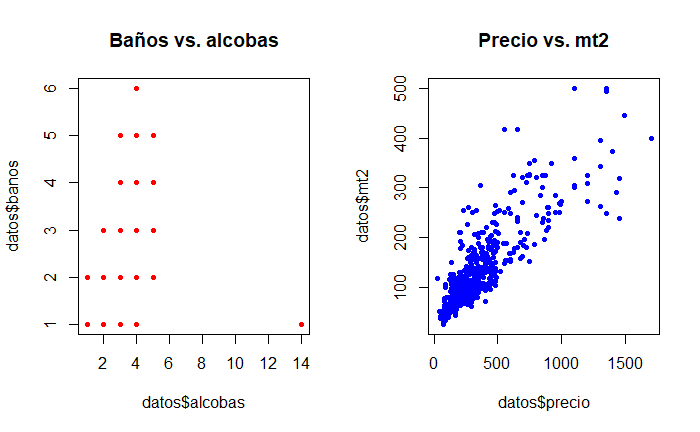

```r
par(mfrow = c(1, 2))
plot(datos$alcobas,datos$banos, pch = 20, col = "red", main = "Baños vs. alcobas")
plot(datos$precio,datos$mt2, pch = 20, col = "blue", main = "Precio vs. mt2")
```

## 8.1 Propiedades de la Correlacion

```r
cor(datos$precio,datos$avaluo)
```

```
[1] 0.7895324
```

Cambiando de escala

```r
cor(datos$precio*100, datos$avaluo*5)
```

```
[1] 0.7895324
```

Ante los cambios de escala el coeficiente de correlación NO varia.